# Run the model

Villaseñor-Derbez J.C.

Updated on 2022-06-01

# Setup

## Load packages and functions

```r
# Load libraries
suppressPackageStartupMessages({
  library(startR)
  library(magrittr)
  library(here)
  library(cowplot)
  library(furrr)
  library(tidyverse)
})

# Load functions
source(here("scripts", "3_model", "grow.R"))
source(here("scripts", "3_model", "E_vec_fxn.R"))
source(here("scripts", "3_model", "pi_of_E.R"))
source(here("scripts", "3_model", "max_Ei.R"))
source(here("scripts", "3_model", "solve_pi.R"))
source(here("scripts", "3_model", "PNA_with_trading.R"))
source(here("scripts", "3_model", "PNA_no_trading.R"))

# Some housekeeping
update_geom_defaults("point",
                     list(
                       fill = "steelblue",
                       color = "black",
                       shape = 21,
                       size = 3
                     ))


update_geom_defaults("line", list(color = "black",
                                  size = 1))

theme_set(startR::ggtheme_plot())
```

## Description of simulations

We inform our model to losely match the fishery dynamics observed for the VDS operated by the PNA. The table below contains the values used to parameterize the model.

### Define parameters

```r
# Reserve properties
theta <- 1
R <- 0

# Bio
MSY <- 1875600 # 50th percentile from MSY in table 8 of SA (https://www.wcpfc.int/node/27490)
Bmsy <- 1628000 # 50th percentile from SBmsy in table 8 of SA (https://www.wcpfc.int/node/27490)
K <- 6876526 # 50th percentile from SB_f0 in table 8 of SA (https://www.wcpfc.int/node/27490)
Bc_B0 <- 0.51 # 50th percentile from SBlatest/SB_fo in table 8 of SA (https://www.wcpfc.int/node/27490)
Cnow <- 1679444 # Catches now
Bnow <- K * Bc_B0 # current Biomass (2012 - 2015 average)
r <- 0.57 # From fishbase: Prior r = 0.57, 95% CL = 0.41 - 0.78 (https://www.fishbase.in/summary/107#)

# Economic
beta <- 1.3
p <- 1100 # (1447 + 1467) / 2 #mean between thailand and japan values (Value of WCPFC-CA tuna fisheries 2017 report)
E <- 45000
q <- 12 / (0.1 * Bnow) # 2 * (0.8 * Cnow) / (E * 0.8 * Bnow)
c <- 180 # 340

# Vectors of initial biomass and movement
# Proportional size of the high seas
prop_hs <- 0.1
# Number of patches
n_patches <- 10
# Biomass redistribution vector
fvec <- c(rep(((1 - prop_hs) / (n_patches - 1)), (n_patches - 1)), prop_hs)
# fvec <- c(0.12, 0.08, 0.07, 0.13, 0.07, 0.12, 0.09, 0.12, 0.1, 0.1)
names(fvec) <- c("KIR", "FSM", "MHL", "NRU", "PLW", "PNG", "SLB", "TKL", "TUV", "HS")
Xvec <- Bnow * fvec
```

### Create and export a table of parameters and sources

Create a table

```r
params <- tibble(
  parameter = c(
    "MSY",
    "$B_{msy}$",
    "K",
    "$B_c/B_{msy}$",
    "$C_{now}$",
    "$B_{now}$",
    "$r$",
    "$\\beta$",
    "p",
    "q",
    "c",
    "f"
  ),
  value = c(MSY, Bmsy, K, Bc_B0, Cnow, Bnow, r, beta, p, q, c, 0.1),
  source = c(
    "50th percentile from MSY in table 8 of Stock Assessment",
    "50th percentile from MSY in table 8 of Stock Assessment",
    "50th percentile from MSY in table 8 of Stock Assessment",
    "50th percentile from MSY in table 8 of Stock Assessment",
    "Catches from Stock Assessment",
    "Current Biomass (2012 - 2015 average)",
    "From fishbase: Prior r = 0.57, 95 CL = 0.41 - 0.78",
    "Standard",
    "Mean between Thailand and Japan values (Value of WCPFC-CA tuna fisheries 2017 report)",
    "Estimated so that efforts match catches given biomass and vessel-day prices",
    "-",
    "Biomass is equally distributed between patches ($f_i = 0.1$)"

  )
)

params %>%
  knitr::kable(col.names = c("Parameter", "Value", "Source"),
               format = "html",
               escape = F) %>%
  kableExtra::kable_styling(latex_options = "scale_down")
```

Parameter

Value

Source

MSY

1.875600e+06

50th percentile from MSY in table 8 of Stock Assessment

$B_{msy}$

1.628000e+06

50th percentile from MSY in table 8 of Stock Assessment

K

6.876526e+06

50th percentile from MSY in table 8 of Stock Assessment

$B_c/B_{msy}$

5.100000e-01

50th percentile from MSY in table 8 of Stock Assessment

$C_{now}$

1.679444e+06

Catches from Stock Assessment

$B_{now}$

3.507028e+06

Current Biomass (2012 - 2015 average)

$r$

5.700000e-01

From fishbase: Prior r = 0.57, 95 CL = 0.41 - 0.78

$\beta$

1.300000e+00

Standard

p

1.100000e+03

Mean between Thailand and Japan values (Value of WCPFC-CA tuna fisheries 2017 report)

q

3.420000e-05

Estimated so that efforts match catches given biomass and vessel-day prices

c

1.800000e+02

f

1.000000e-01

Biomass is equally distributed between patches ($f_i = 0.1$)

Export the table

```r
params %>%
  knitr::kable(col.names = c("Parameter", "Value", "Source"),
               format = "latex",
               escape = F) %>%
  kableExtra::kable_styling(latex_options = "scale_down") %>%
  cat(file = here("docs", "tab", "parameters.tex"))
```

The second scenario allows trading. We start again by solving for the high seas to obtain total effort. Since a closure is not in effect, this equiulibrium is the same as the first step above. We then implement a spatial closure in patch 1. This essentially lowers the price fishers would be willing to pay to fish in a patch with biomass $X_i\Omega_i$, lowering demand for vessel-days in pach 1. Patches 2 - 9 have a higher demand for vessel days, and therefore a portion of vessel-days from patch 1 are sold to patches 2 - 9. This increases effort in these patches, which reduces escapement and therefore biomass. This reduction in biomass in turn would modify the demand curves (Ei). We therefore iterate this process until biomass stabilizes, therefore finding the system’s equilibrium. Like before, we calculate vessel-day revenues to each patch and compare them to a case with no reserve in patch 1.

# Cost of a reserve is governed by fish movement

> Less movement leads to higer costs

This first par uses no trading, but allows us to look at how movement ($\theta$) governs costs. The intuition is that, given the parameterization, high movement rates will lead to low costs because:

$$\Omega = \theta + (1 - \theta)(1 - R)$$

This shows that, no matter what the size of the reserve is, when $\theta = 1$, $\Omega = 1$.

## Get initial conditions

We first run a model that allows for trading to get the Effort vector that would maximize $pi$.

```r
Benchmark_results <-
  PNA_with_trading(
    fvec = fvec,
    theta = theta,
    R = R,
    r = r,
    K = K,
    p = p,
    q = q,
    Xvec = Xvec,
    beta = beta,
    c = c,
    E = E
  ) %>%
  select(
    Country,
    b_harvest = Harvest,
    b_vessel_days = Vessel_Days,
    b_stock = Stock,
    b_stock_i = Stock_i,
    b_vdsprice = VDSprice,
    b_vdsrevenue = VDSrevenue,
    b_vdsrevenue_all = VDSrevenue_all,
    b_vdsrevenue_notKIR = VDSrevenue_notKIR
  )
```

We then take these results, and use the observed efforts as the optimal efforts.

```r
Evec <- Benchmark_results$b_vessel_days

Evec
```

```
##         KIR         FSM         MHL         NRU         PLW         PNG
##    5000.146    5000.146    5000.146    5000.146    5000.146    5000.146
##         SLB         TKL         TUV          HS
##    5000.146    5000.146    5000.146 1556335.016
```

## Run the model

We now run the model with **NO** trading, using the Evec above as starting condition.

```r
# Create combinations of R and theta
Rvec <- seq(0, 1, 0.05)
thetavec <- seq(0, 1, 0.1)

DF_results_no_trading <-
  expand.grid(R = Rvec, theta = thetavec) %>%
  mutate(
    res = map2(
      theta,
      R,
      PNA_no_trading,
      fvec = fvec,
      r = r,
      K = K,
      p = p,
      q = q,
      Xvec = Xvec,
      beta = beta,
      c = c,
      Evec = Evec
    )
  ) %>%
  unnest()
no_trade_bm <- DF_results_no_trading %>%
  filter(R == 0, theta == 0) %>%
  select(
    Country,
    b_harvest = Harvest,
    b_vessel_days = Vessel_Days,
    b_stock = Stock,
    b_stock_i = Stock_i,
    b_vdsprice = VDSprice,
    b_vdsrevenue = VDSrevenue,
    b_vdsrevenue_all = VDSrevenue_all,
    b_vdsrevenue_notKIR = VDSrevenue_notKIR
  )
```

We now take these results and add the benchmark results (no reserve) to calculate the cost of the reserve as the change in revenue. The proportional way of saying this is:

$$\%C_R = \frac{\Pi_{R = 0} - \Pi_{R = r}}{\Pi_{R = 0}}$$
Where $\Pi_{R = 0}$ is the vessel-day revenue when there is no reserve, hence the $R = 0$ subindex. The $\Pi_{R = r}$ denotes the vessel-day revenues when reserve has size ($r \in (0, 1)$). The vessel-day revenue is simply the vessel-day price times the number of vessel-days in patch $i$: $\pi \times E_i$.

```r
DF_1_no_trading <- DF_results_no_trading %>%
  filter(Country == "KIR") %>%
  left_join(no_trade_bm, by = "Country") %>%
  mutate(
    cost = b_vdsrevenue - VDSrevenue,
    rel_cost = cost / b_vdsrevenue,
    cost_pna_not_kir = VDSrevenue_notKIR - b_vdsrevenue_notKIR,
    rel_cost_pna_not_kir = cost_pna_not_kir / b_vdsrevenue_notKIR,
    cost_all = VDSrevenue_all - b_vdsrevenue_all,
    rel_cost_all = cost_all / b_vdsrevenue_all
  )
```

We can now go ahead and plot these results. The figure below shows the $C_R$ defined above for different size of reserves $R$ in the x-axis, given values of $theta$ (colors). The graph shows how a smaller movement rate leads to increased costs to the country that implements the reserve. A movement of $\theta = 1$ implies no reserve, and thus leads to no losses. However, this parameter is unlikely. We also see how the losses are not proportional to 1. That is, a 10% closure does not lead to a 10% loss in profits.

**Is this due to the concavity in costs? i.e. the $\beta$ parameter$?**

Yes, it looks like a $\beta = 1.1$ actually reduces this.

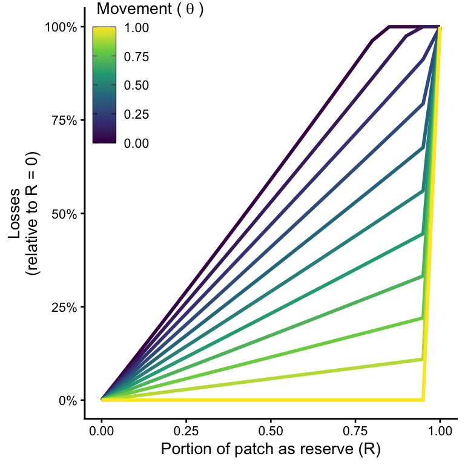

```r
(
  costs_no_trading_plot <-
    ggplot(data = DF_1_no_trading) +
    geom_line(aes(
      x = R,
      y = rel_cost,
      group = theta,
      color = theta
    ),
    size = 1
    ) +
    xlab("Portion of patch as reserve (R)") +
    ylab("Losses\n(relative to R = 0)") +
    scale_color_viridis_c() +
    theme(
      text = element_text(size = 10),
      axis.text = element_text(size = 8)
    ) +
    # startR::ggtheme_plot() +
    scale_y_continuous(labels = scales::percent) +
    guides(color = guide_colorbar(title = quo("Movement ("~theta~")"),
                                  ticks.colour = "black", frame.colour = "black")) +
    theme(legend.justification = c(0, 0.9),
          legend.position = c(0, 1))
)
```

```r
ggsave(plot = costs_no_trading_plot,
       filename = here("docs", "diss_img", "cost_no_trading.png"),
       width = 6,
       height = 4.5)
```

# Trading affects costs

> Trading reduces costs to implementing party

We now run the same model, with same initial conditions, but allow trading as a reserve is closed.

```r
DF_results_with_trading <-
  expand.grid(R = Rvec, theta = thetavec) %>%
  mutate(
    res = map2(
      theta,
      R,
      PNA_with_trading,
      fvec = fvec,
      r = r,
      K = K,
      p = p,
      q = q,
      Xvec = Xvec,
      beta = beta,
      c = c,
      E = sum(Evec[1:9])
    )
  ) %>%
  unnest()
trading_bm <- DF_results_with_trading %>%
  filter(R == 0, theta == 0) %>%
  select(
    Country,
    b_harvest = Harvest,
    b_vessel_days = Vessel_Days,
    b_stock = Stock,
    b_stock_i = Stock_i,
    b_vdsprice = VDSprice,
    b_vdsrevenue = VDSrevenue,
    b_vdsrevenue_all = VDSrevenue_all,
    b_vdsrevenue_notKIR = VDSrevenue_notKIR
  )
```

Again, put it together with the reference values to calculate costs.

```r
DF_1_with_trading <- DF_results_with_trading %>%
  filter(Country == "KIR") %>%
  left_join(trading_bm, by = "Country") %>%
  mutate(
    vessel_days_sold = b_vessel_days - Vessel_Days,
    sales_revenue = vessel_days_sold * VDSprice,
    all_VDSrevenue = VDSrevenue + sales_revenue,
    cost = b_vdsrevenue - all_VDSrevenue,
    rel_cost = cost / b_vdsrevenue,
    cost_pna_not_kir = VDSrevenue_notKIR - b_vdsrevenue_notKIR - sales_revenue,
    rel_cost_pna_not_kir = cost_pna_not_kir / b_vdsrevenue_notKIR,
    cost_all = VDSrevenue_all - b_vdsrevenue_all,
    rel_cost_all = cost_all / b_vdsrevenue_all
  )
```

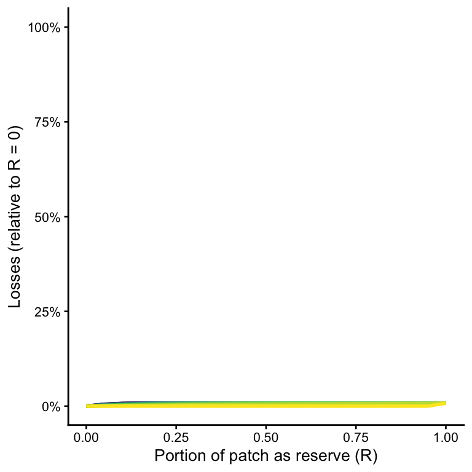

```r
(costs_with_trading_plot_long_axis <- ggplot(data = DF_1_with_trading) +
  geom_line(aes(
    x = R,
    y = rel_cost,
    group = theta,
    color = theta
  ),
  size = 1
  ) +
  xlab("Portion of patch as reserve (R)") +
  ylab("Losses (relative to R = 0)") +
  scale_color_viridis_c() +
  # startR::ggtheme_plot() +
  scale_y_continuous(labels = scales::percent, limits = c(0, 1)) +
  theme(legend.position = "None"))
```

```r
ggsave(plot = costs_with_trading_plot_long_axis,
       filename = here("docs", "diss_img", "cost_with_trading_long_axis.png"),
       width = 6,
       height = 4.5)
```

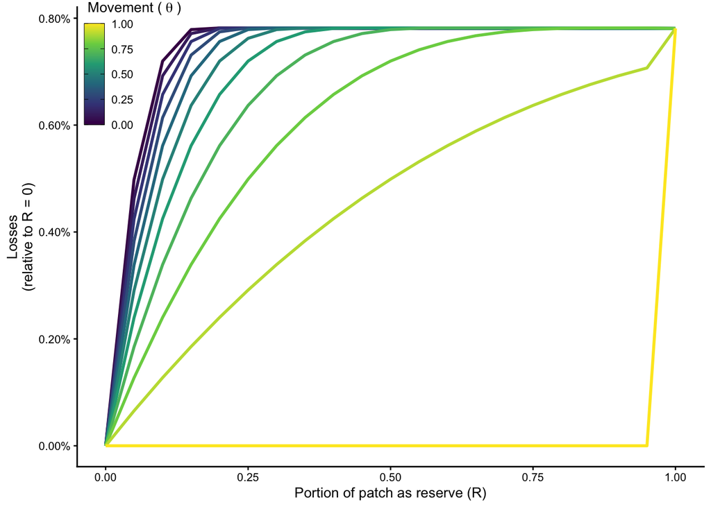

```r
(costs_with_trading_plot <- ggplot(data = DF_1_with_trading) +
  geom_line(aes(
    x = R,
    y = rel_cost,
    group = theta,
    color = theta
  ),
  size = 1
  ) +
  xlab("Portion of patch as reserve (R)") +
  ylab("Losses\n(relative to R = 0)") +
  scale_color_viridis_c() +
  # startR::ggtheme_plot() +
  scale_y_continuous(labels = scales::percent_format(accuracy = 0.01)) +
    guides(color = guide_colorbar(title = quo("Movement ("~theta~")"),
                                  ticks.colour = "black", frame.colour = "black")) +
    theme(legend.justification = c(0, 0.9),
          legend.position = c(0, 1))
)
```

```r
ggsave(plot = costs_with_trading_plot,
       filename = here("docs", "diss_img", "cost_with_trading.png"),
       width = 6,
       height = 4.5)
```

## Cost reduction due to trading

```r
shorter_no_trading <- DF_1_no_trading %>%
  select(Country, R, theta, Vessel_Days, VDSprice, VDSrevenue, cost, rel_cost)

shorter_trading <- DF_1_with_trading %>%
  select(Country, R, theta, Vessel_Days_trading = Vessel_Days, pi_trading = VDSprice, VDSrevenue_trading = all_VDSrevenue, cost_trading = cost, rel_cost_trading = rel_cost)

both <- left_join(shorter_no_trading, shorter_trading, by = c("Country", "R", "theta")) %>%
  mutate(delta_cost = cost - cost_trading,
         rel_delta_cost = delta_cost / cost) %>%
  filter(!R == 0,
         !theta == 1)
```

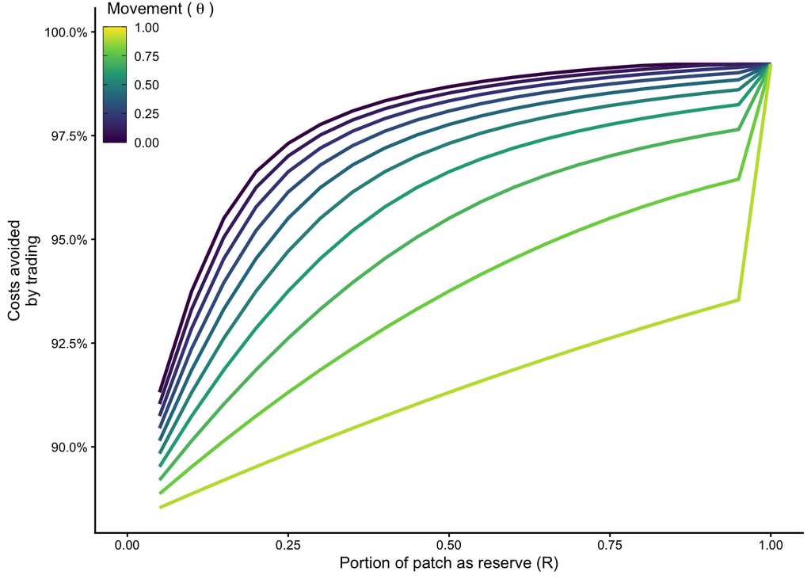

```r
(delta_costs_plot <- ggplot(data = both) +
  geom_line(aes(
    x = R,
    y = rel_delta_cost,
    group = theta,
    color = theta
  ),
  size = 1
  ) +
  xlab("Portion of patch as reserve (R)") +
  ylab("Costs avoided\nby trading") +
  scale_color_viridis_c(limits = c(0, 1)) +
  theme(
    text = element_text(size = 10),
    axis.text = element_text(size = 8)
  ) +
  # startR::ggtheme_plot() +
  scale_y_continuous(labels = scales::percent_format(accuracy = 0.1),
                     limits = c(0.885, 1)) +
  scale_x_continuous(limits= c(0, 1)) +
    guides(color = guide_colorbar(title = quo("Movement ("~theta~")"),
                                  ticks.colour = "black", frame.colour = "black")) +
    theme(legend.justification = c(0, 0.9),
          legend.position = c(0, 1))
)
```

```r
ggsave(plot = delta_costs_plot,
       filename = here("docs", "diss_img", "panel2c.pdf"),
       width = 3.4, height = 2.3)

ggsave(plot = delta_costs_plot,
       filename = here("docs", "diss_img", "panel2c.png"),
       width = 6,
       height = 4.5)
```

All together

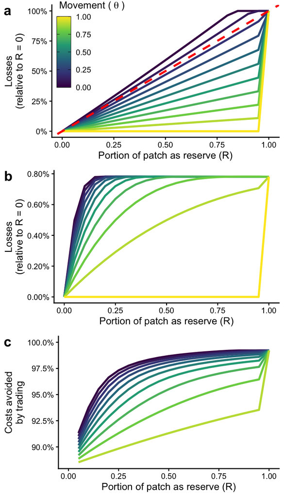

```r
(cost_plot <- plot_grid(costs_no_trading_plot +
                          geom_abline(intercept = 0, slope = 1, size = 1, linetype = "dashed", color = "red"),
                        costs_with_trading_plot +
                          theme(legend.position = "None"),
                        delta_costs_plot  +
                          theme(legend.position = "None"),
                        ncol = 1,
                        labels = "auto"))
```

Now let’s save this figure.

```r
ggsave(plot = cost_plot,
       filename = here("docs", "diss_img", "PNA_model.pdf"),
       width = 3.4,
       height = 7)
```

# Change in effort and revenue with and without trading

```r
# Create a data.frame of effort by scenario
effort <- both %>% select(R, theta, Vessel_Days, Vessel_Days_trading) %>%
  gather(model, effort, -c(R, theta)) %>%
  mutate(model = ifelse(str_detect(model, "trading"), "Trading", "No trading"))

# Repeat for revenues and merge
revenues <- both %>% select(R, theta, VDSrevenue, VDSrevenue_trading) %>%
  gather(model, revenues, -c(R, theta)) %>%
  mutate(model = ifelse(str_detect(model, "trading"), "Trading", "No trading")) %>%
  left_join(effort, by = c("R", "theta", "model"))
```

Plot it

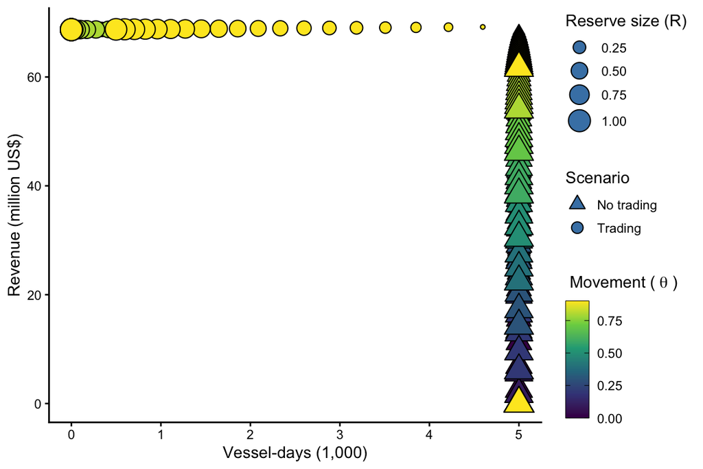

```r
(
  effort_and_revenues <- ggplot(data = revenues,
                                mapping = aes(x = effort / 1e3,
                                              y = revenues / 1e6,
                                              fill = theta,
                                              size = R,
                                              shape = model)) +
    geom_point(color = "black") +
    scale_fill_viridis_c() +
    scale_shape_manual(values = c(24, 21)) +
    labs(x = "Vessel-days (1,000)", y = "Revenue (million US$)") +
    guides(shape = guide_legend(title = "Scenario"),
           size = guide_legend(title = "Reserve size (R)"),
           fill = guide_colorbar(title = quo("Movement ("~theta~")"),
                                 frame.colour = "black",
                                 ticks.colour = "black"))
)
```

Save it

```r
ggsave(plot = effort_and_revenues,
       file = here("docs", "diss_img", "effort_and_revenues.pdf"),
       width = 6,
       height = 4)
```

```r
ggsave(plot = effort_and_revenues,
       here("docs", "diss_img", "effort_and_revenues_ED_Fig4.tiff"),
       width = 6,
       height = 4)
```

## How does vessel-price change?

### When there’s no trading

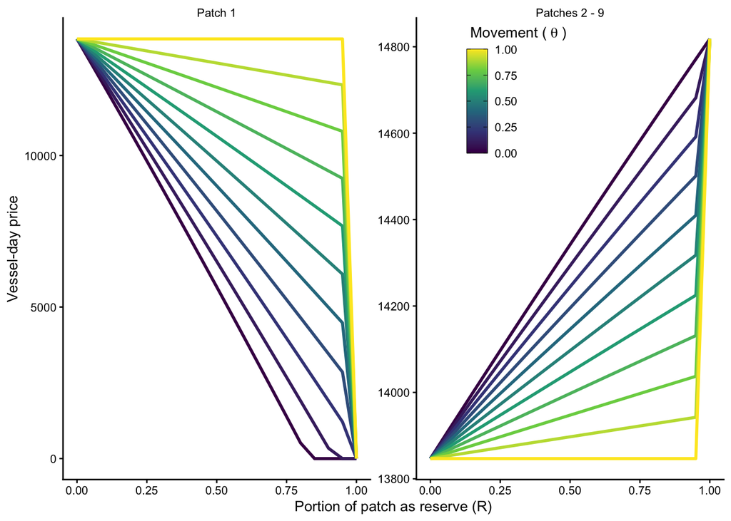

```r
country_anom <- tibble(Country = c("KIR", "FSM", "MHL", "NRU", "PLW", "PNG", "SLB", "TKL","TUV","HS"),
                       Country_a = 1:10)

(vessel_day_price_no_trading_plot <-
    DF_results_no_trading %>%
    left_join(country_anom, by = "Country") %>%
    filter(Country_a %in% c(1, 2)) %>%
    mutate(Country_a = ifelse(Country_a == 1, "Patch 1", "Patches 2 - 9"),
           Country_a = fct_relevel(Country_a, "Patch 1")) %>%
    ggplot(aes(x = R, y = VDSprice, color = theta, group = theta)) +
    geom_line(size = 1) +
    facet_wrap( ~ Country_a, scale = "free_y") +
    xlab("Portion of patch as reserve (R)") +
    ylab("Vessel-day price") +
    scale_color_viridis_c() +
    theme(
      text = element_text(size = 10),
      axis.text = element_text(size = 8)
    ) +
    startR::ggtheme_plot() +
    guides(color = guide_colorbar(title = quo("Movement ("~theta~")"),
                                  ticks.colour = "black", frame.colour = "black"))+
    theme(legend.position = c(0.6, 1),
          legend.justification = c(0, 1)))
```

```r
ggsave(plot = vessel_day_price_no_trading_plot,
       filename = here("docs", "diss_img", "vessel_day_price_no_trading_plot.pdf"),
       width = 6,
       height = 3)
```

```r
ggsave(plot = vessel_day_price_no_trading_plot,
       here("docs", "diss_img", "vessel_day_price_no_trading_plot_ED_Fig1.tiff"),
       width = 6,
       height = 3)
```

### When there is trading

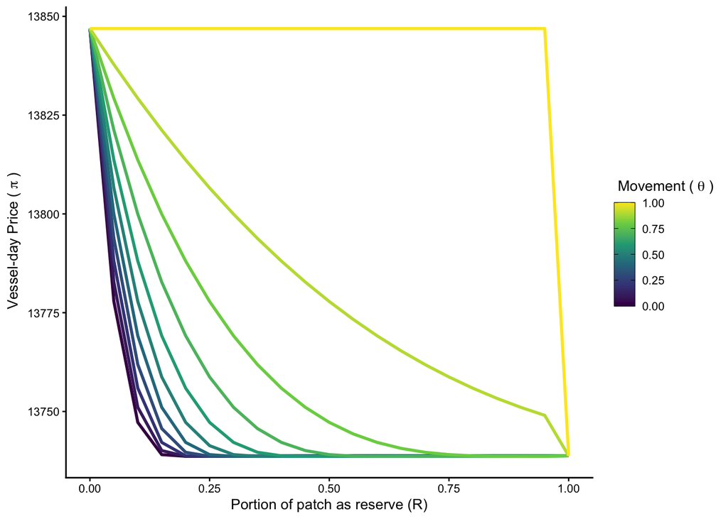

```r
(vessel_day_price_with_trading_plot <- ggplot(data = DF_1_with_trading) +
   geom_line(aes(
     x = R,
     y = VDSprice,
     group = theta,
     color = theta
   ),
   size = 1
   ) +
   xlab("Portion of patch as reserve (R)") +
   ylab(quo("Vessel-day Price ("~pi~")")) +
   scale_color_viridis_c() +
   theme(
     text = element_text(size = 10),
     axis.text = element_text(size = 8)
   ) +
   startR::ggtheme_plot() +
   guides(color = guide_colorbar(title = quo("Movement ("~theta~")"),
                                 ticks.colour = "black",
                                 frame.colour = "black")))
```

```r
ggsave(plot = vessel_day_price_with_trading_plot,
       here("docs", "diss_img", "vessel_day_price_with_trading_plot.pdf"),
       width = 6,
       height = 4.5)
```

```r
ggsave(plot = vessel_day_price_with_trading_plot,
       here("docs", "diss_img", "vessel_day_price_with_trading_plot_ED_Fig3.tiff"),
       width = 6,
       height = 4.5)
```

## What about revenue to other PNA countries?

### With no trading

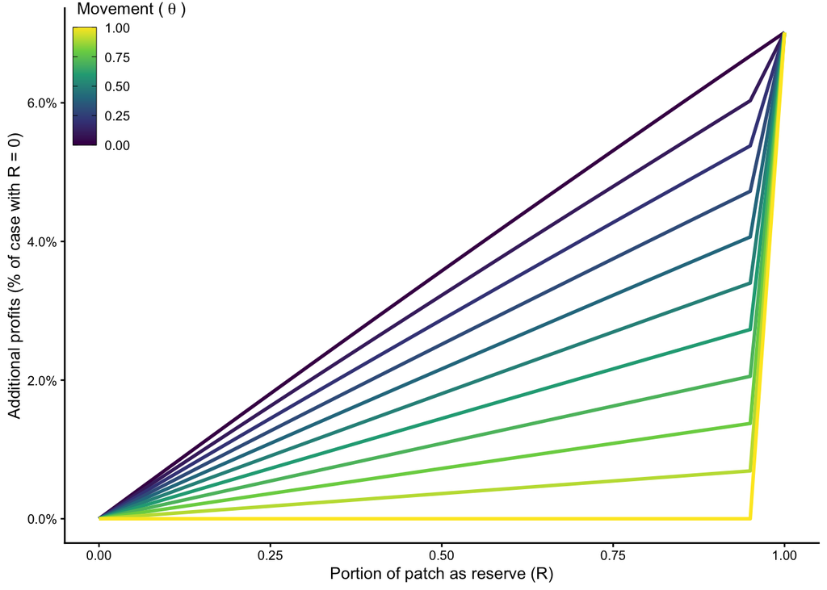

```r
(
  profits_PNA_notKIR_no_trading_plot <-
    ggplot(data = DF_1_no_trading) +
    geom_line(aes(
      x = R,
      y = rel_cost_pna_not_kir,
      group = theta,
      color = theta
    ),
    size = 1
    ) +
    xlab("Portion of patch as reserve (R)") +
    ylab("Additional profits (% of case with R = 0)") +
    scale_color_viridis_c() +
    theme(
      text = element_text(size = 10),
      axis.text = element_text(size = 8)
    ) +
    startR::ggtheme_plot() +
    scale_y_continuous(labels = scales::percent) +
    guides(color = guide_colorbar(title = quo("Movement ("~theta~")"),
                                  ticks.colour = "black", frame.colour = "black")) +
    theme(legend.justification = c(0, 0.9),
          legend.position = c(0, 1))
)
```

```r
ggsave(plot = profits_PNA_notKIR_no_trading_plot,
       here("docs", "diss_img", "profits_PNA_notKIR_no_trading_plot.pdf"),
       width = 3,
       height = 3)
```

```r
ggsave(plot = profits_PNA_notKIR_no_trading_plot,
       here("docs", "diss_img", "profits_PNA_notKIR_no_trading_plot_ED_Fig2.tiff"),
       width = 3,
       height = 3)
```